# Chapter 05, Problem Set Key

### 5.1

Choose 75 random numbers between 0 and 400. Di it again and pair the numbers with those of the first set. Imagine that these paris of numbers are cooridnates of trees in a plot in a forest (400 x 400 meters), and graph the points (i.e., make a map of the locations of the trees). Place a grid of 100 x 100 hectares on the map, count the number of trees in each hectare, and make a graph of the relative frequency of different counts. Now group the hectare classes by threes (i.e., combine the frequency of hectares that have 0, 1, or 2 trees into a single class, the hectares that have 3, 4, or 5 in a distinct class, etc.), and recalculate the relative frequencies. What does the comparison of the frequency distribution when groups by ones versus threes tell you?

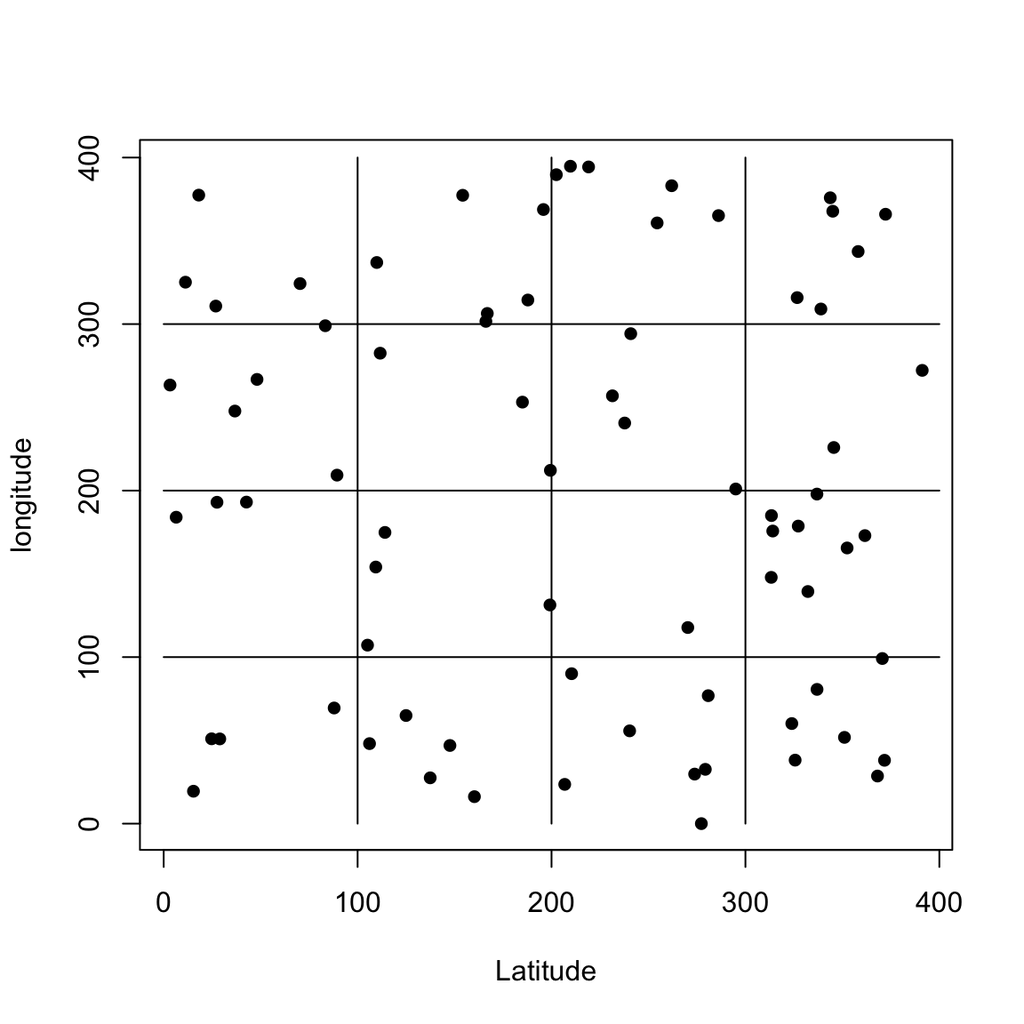

```r
set.seed(6174)

points <- 75
plot.min <- 0
plot.max <- 400

x <- runif(n = points, min = plot.min, max = plot.max)
y <- runif(n = points, min = plot.min, max = plot.max)

interior.segs <- seq(from = 100, to = 300, by = 100)
n.segs <- length(interior.segs)

plot(x = x, y = y, xlab = "Latitude", ylab = "longitude", pch = 16)
segments(x0 = interior.segs, x1 = interior.segs, y0 = rep(x = plot.min, times = n.segs), y1 = rep(x = plot.max, times = n.segs))
segments(x0 = rep(x = plot.min, times = n.segs), x1 = rep(x = plot.max, times = n.segs), y0 = interior.segs, y1 = interior.segs)
```

```r
counts <- matrix(data = c(4, 0, 4, 2, 6, 5, 7, 3, 2, 4, 8, 4, 2, 4, 10, 10), nrow = 4, ncol = 4)
if (sum(counts) != 75) {warning("Learn to count, Chris")} else {warning("You're a beautiful counter, Chris")}
```

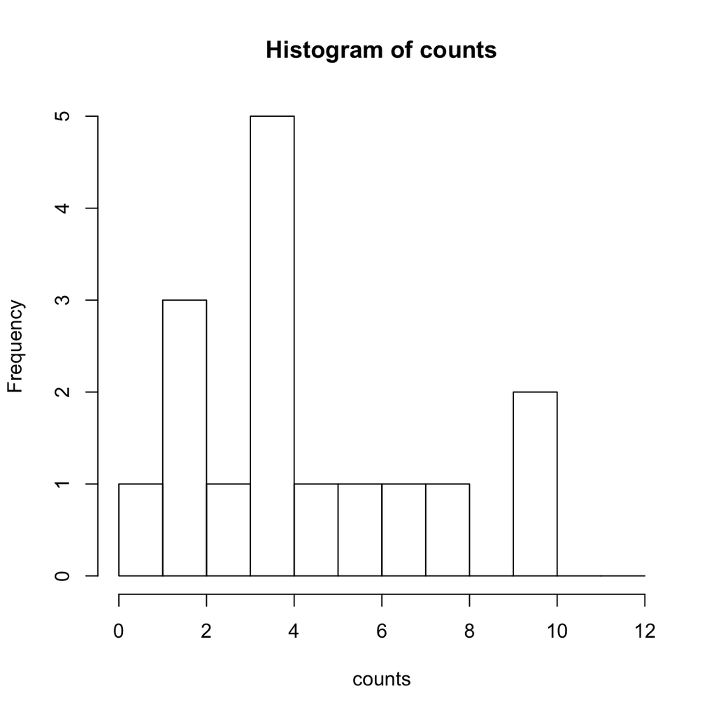

```r
hist(x = counts, breaks = seq(from = 0, to = 12, by = 1))
```

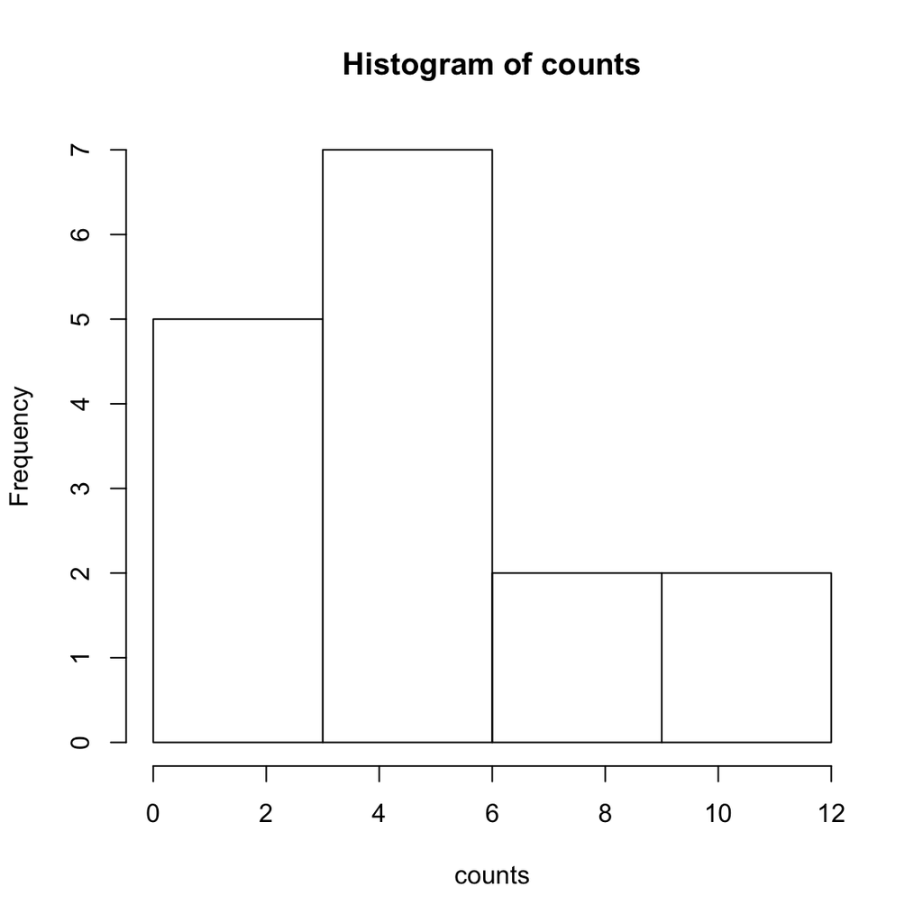

```r
hist(x = counts, breaks = seq(from = 0, to = 12, by = 3))
```

The coarser bin gives a clearer indication of the expected value compared with finer bins.

### 5.2

In a forest plot in Michigan measuring 400 × 400 meters we find 72 American basswood trees with the x and y coordinates as given in the appendix to this chapter. Make a graph of the x coordinates against the y coordinates, and qualitatively compare the pattern you see with the pattern you generated in exercise 5.1. Group the hectare classes by ones (i.e., the frequency of hectares that have 0, the frequency with 1, the frequency with 2, etc.). Group the hectare classes by threes (i.e., the frequency of hect- ares that have between 0 and 2 trees, the frequency that have between 3 and 5, the frequency that have between 6 and 8, etc). Compare the relative frequencies for the groups classed by ones and that classed by threes.

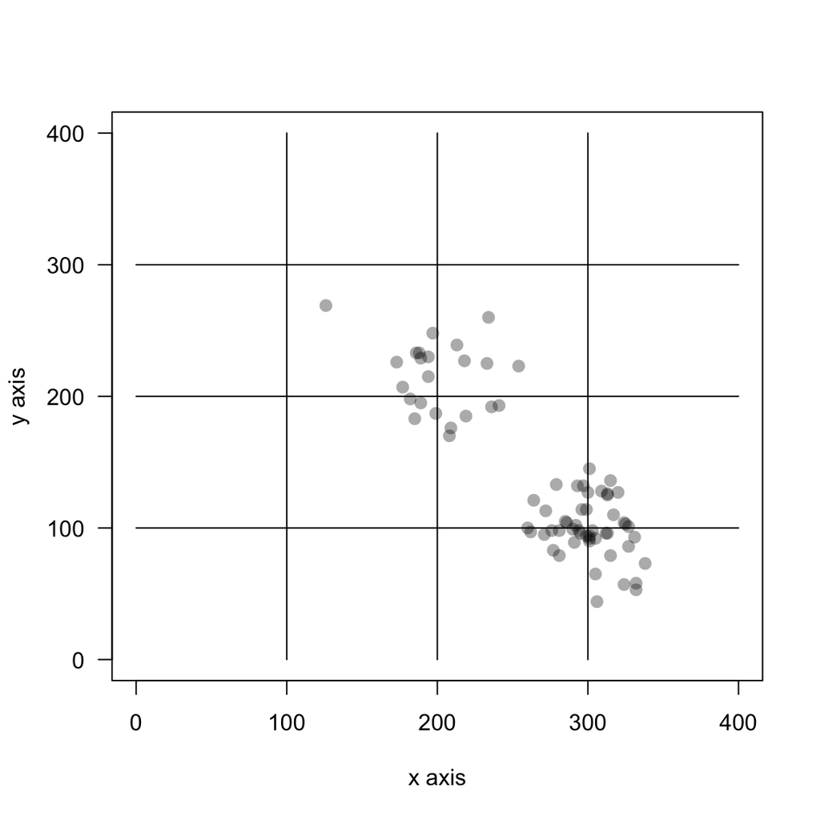

```r
# Set to where your data live
data.dir <- "/Volumes/GoogleDrive/My Drive/BI382/2019Spring/Discussions/ProblemNotes"

basswood <- read.csv(file = paste0(data.dir, "/Ch05_BassData.csv"))
plot(x = basswood[,2], y = basswood[,3], xlab = "x axis", ylab = "y axis", las = 1, xlim = c(0, 400), ylim = c(0, 400), pch = 16, col = "#00000055", cex = 1.25)

segments(x0 = interior.segs, x1 = interior.segs, y0 = rep(x = plot.min, times = n.segs), y1 = rep(x = plot.max, times = n.segs))
segments(x0 = rep(x = plot.min, times = n.segs), x1 = rep(x = plot.max, times = n.segs), y0 = interior.segs, y1 = interior.segs)
```

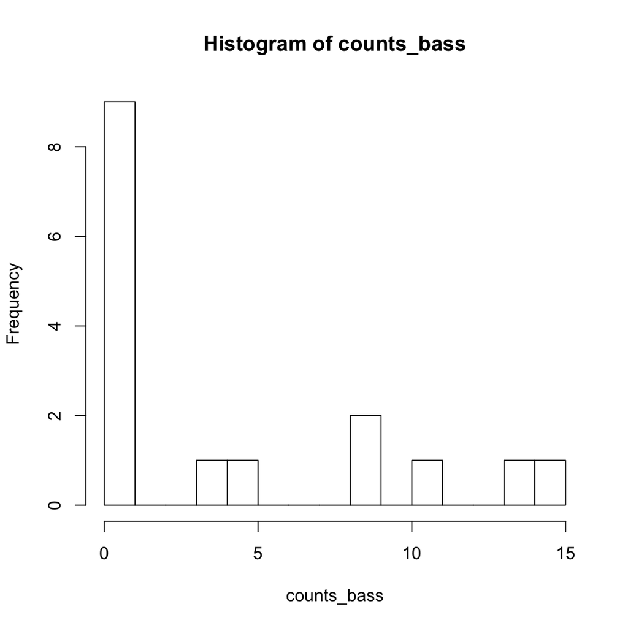

```r
counts_bass <- matrix(data = c(0, 0, 0, 0, 0, 9, 4, 0, 0, 5, 15, 11, 0, 0, 9, 14), nrow = 4, ncol = 4)

hist(x = counts_bass, breaks = seq(from = 0, to = 15, by = 1))
```

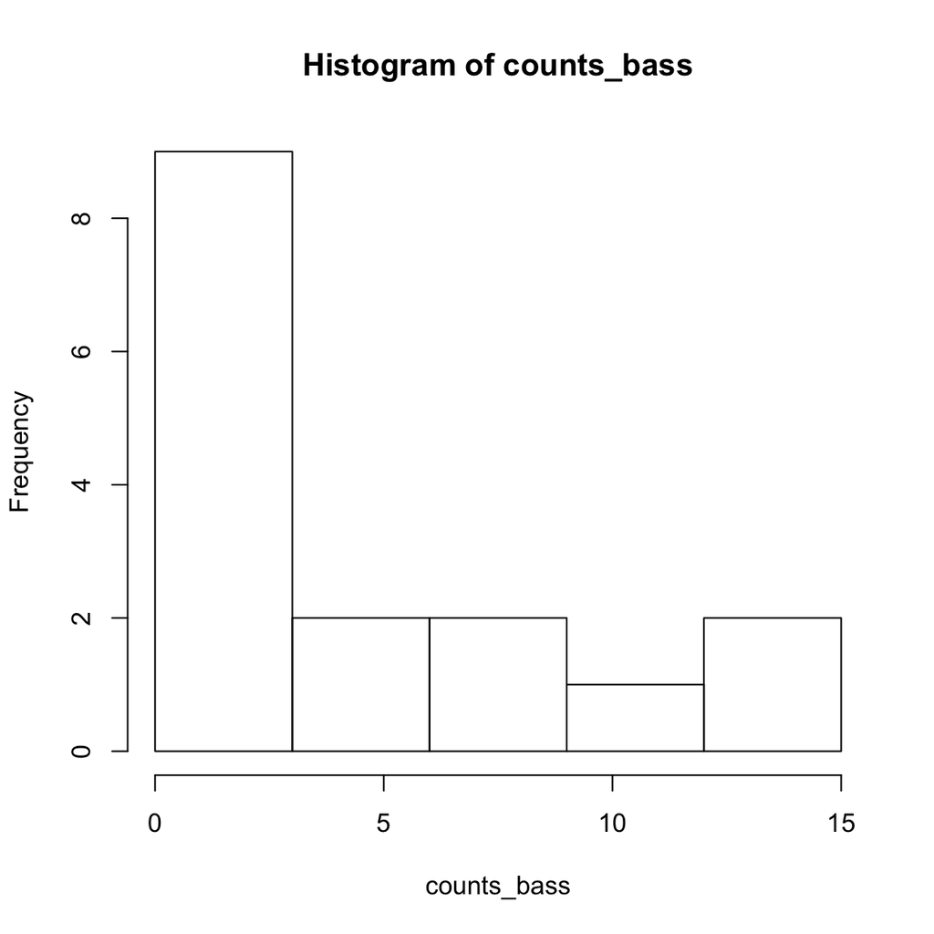

```r
hist(x = counts_bass, breaks = seq(from = 0, to = 15, by = 3))
```

A coarser bin of 3 seems more uniformly distributed.

### 5.3

In the same forest plot of 400 × 400 meters we find 61 American beech trees with the x and y coordinates as given in the appendix to this chapter. Make a graph of the x coor- dinates against the y coordinates, and qualitatively compare the pattern you see with the pattern you generated in exercise 5.1. Group the hectare classes by ones and then by threes, and recalculate the relative frequencies in both cases.

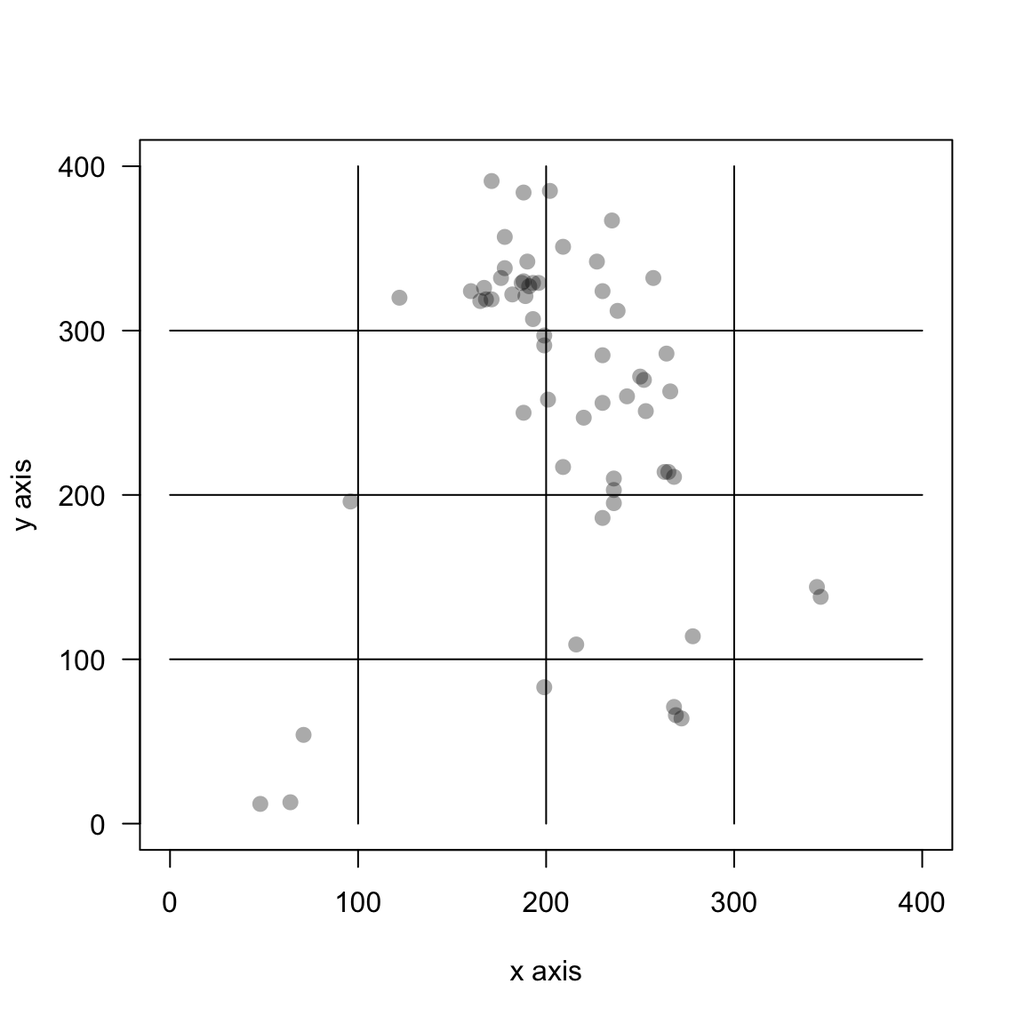

```r
# Set to where your data live
data.dir <- "/Volumes/GoogleDrive/My Drive/BI382/2019Spring/Discussions/ProblemNotes"

beech <- read.csv(file = paste0(data.dir, "/Ch05_BeechData.csv"))
plot(x = beech[,2], y = beech[,3], xlab = "x axis", ylab = "y axis", las = 1, xlim = c(0, 400), ylim = c(0, 400), pch = 16, col = "#00000055", cex = 1.25)

segments(x0 = interior.segs, x1 = interior.segs, y0 = rep(x = plot.min, times = n.segs), y1 = rep(x = plot.max, times = n.segs))
segments(x0 = rep(x = plot.min, times = n.segs), x1 = rep(x = plot.max, times = n.segs), y0 = interior.segs, y1 = interior.segs)
```

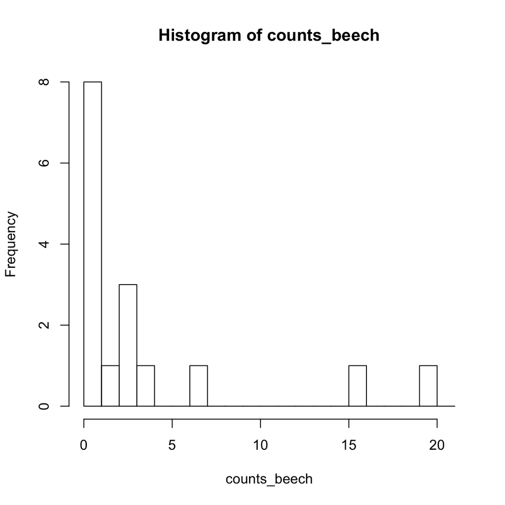

```r
counts_beech <- matrix(data = c(0, 20, 7, 0,
                                0, 3, 16, 0,
                                1, 0, 4, 2,
                                3, 1, 3, 0), nrow = 4, ncol = 4)
hist(x = counts_beech, breaks = seq(from = 0, to = 21, by = 1))
```

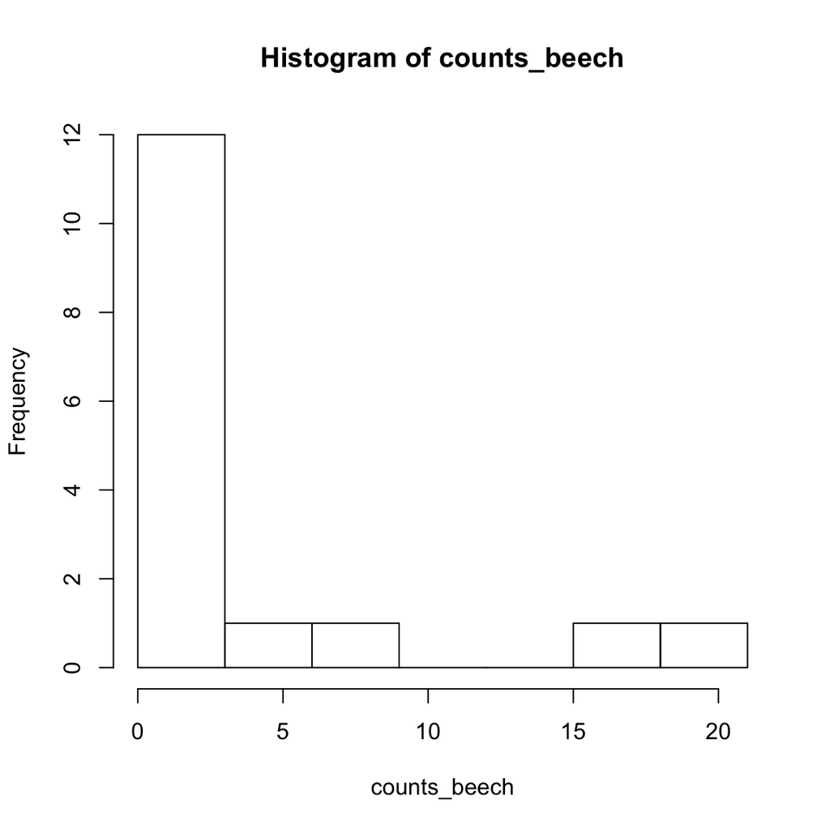

```r
hist(x = counts_beech, breaks = seq(from = 0, to = 21, by = 3))
```

### 5.4

Plot the relative frequencies in the data from exercises 5.1–5.3 on the same graph, and compare the patterns.

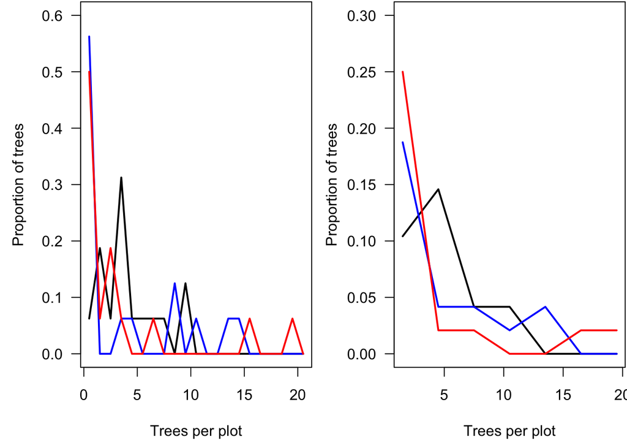

```r
r.hist_1 <- hist(x = counts, breaks = seq(from = 0, to = 21, by = 1), plot = F)
r.hist_3 <- hist(x = counts, breaks = seq(from = 0, to = 21, by = 3), plot = F)
bass.hist_1 <- hist(x = counts_bass, breaks = seq(from = 0, to = 21, by = 1), plot = F)
bass.hist_3 <- hist(x = counts_bass, breaks = seq(from = 0, to = 21, by = 3), plot = F)
beech.hist_1 <- hist(x = counts_beech, breaks = seq(from = 0, to = 21, by = 1), plot = F)
beech.hist_3 <- hist(x = counts_beech, breaks = seq(from = 0, to = 21, by = 3), plot = F)

# mfrow in par() allows you to have rows x columns of plots (here, I make a 1-row, 2-column plot)
par(mfrow = c(1, 2), mar = c(4.5, 4.5, 0.1, 0.1))
plot(x = r.hist_1$mids, y = r.hist_1$density, xlab = "Trees per plot", ylab = "Proportion of trees", type = "l", las = 1, ylim = c(0, 0.6), lwd = 2)
  lines(x = bass.hist_1$mids, y = bass.hist_1$density, lwd = 2, col = "blue")
  lines(x = beech.hist_1$mids, y = beech.hist_1$density, lwd = 2, col = "red")

plot(x = r.hist_3$mids, y = r.hist_3$density, xlab = "Trees per plot", ylab = "Proportion of trees", type = "l", las = 1, ylim = c(0, 0.3), lwd = 2)
  lines(x = bass.hist_3$mids, y = bass.hist_3$density, lwd = 2, col = "blue")
  lines(x = beech.hist_3$mids, y = beech.hist_3$density, lwd = 2, col = "red")
```

The coarse binning makes the distribution more apparent. Even though the random distribution (black) is “random,” the expected pattern of dispersion of trees has a mode than is greater than the trees with non-random distributions.

### 5.5

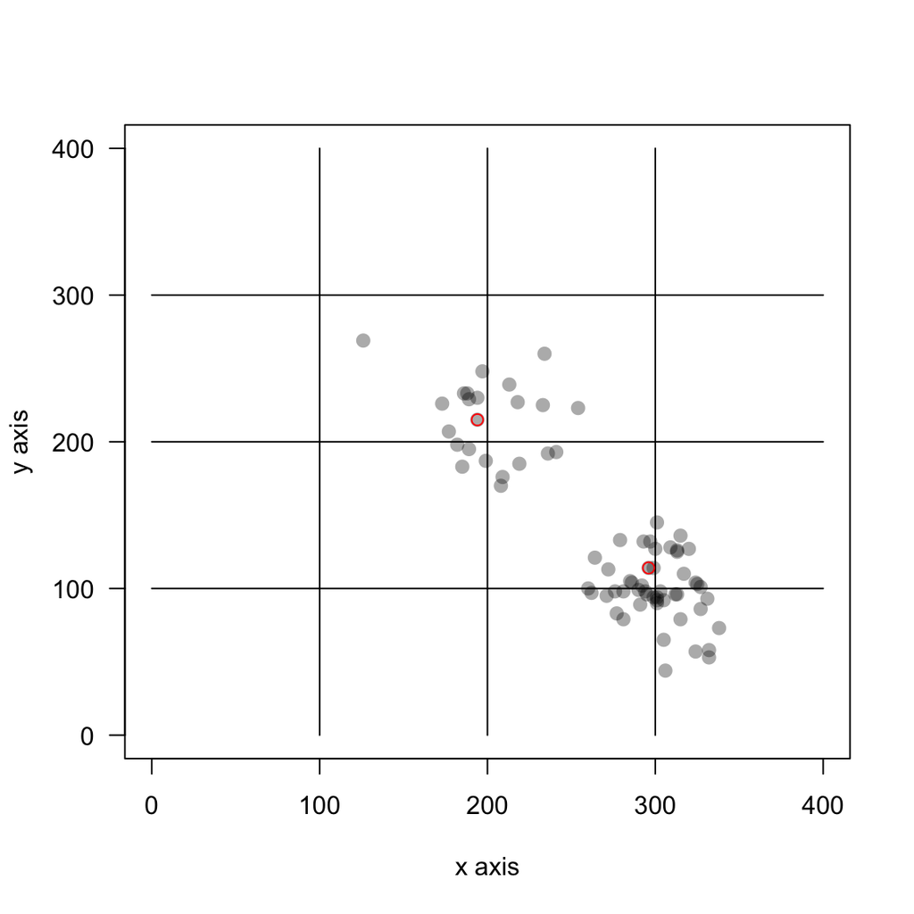

```r
plot(x = basswood[,2], y = basswood[,3], xlab = "x axis", ylab = "y axis", las = 1, xlim = c(0, 400), ylim = c(0, 400), pch = 16, col = "#00000055", cex = 1.25)

segments(x0 = interior.segs, x1 = interior.segs, y0 = rep(x = plot.min, times = n.segs), y1 = rep(x = plot.max, times = n.segs))
segments(x0 = rep(x = plot.min, times = n.segs), x1 = rep(x = plot.max, times = n.segs), y0 = interior.segs, y1 = interior.segs)

points(x = c(194, 296), y = c(215, 114), col = "red")
```

Basswood is dispersed by wind. It looks like most of the seeds to no disperse far from the tree—they are very clumped.

### 5.6

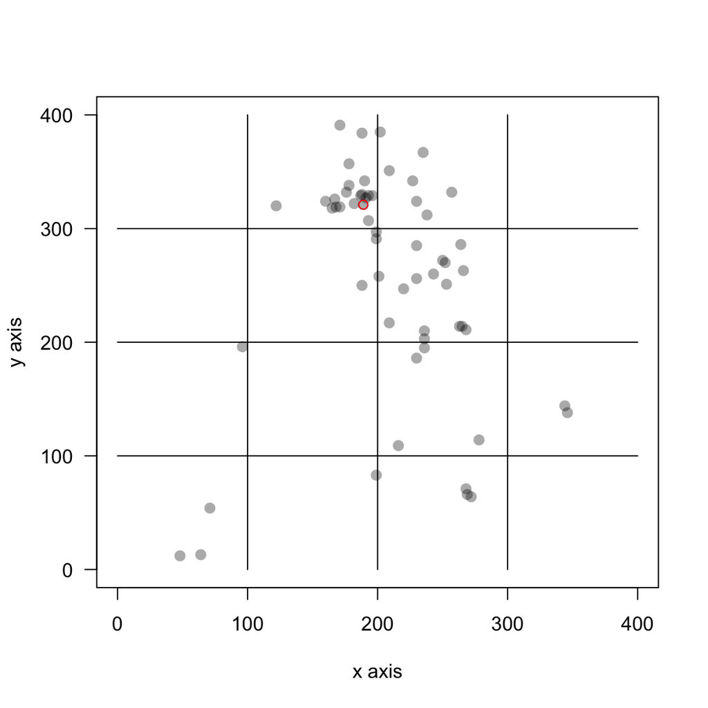

```r
plot(x = beech[,2], y = beech[,3], xlab = "x axis", ylab = "y axis", las = 1, xlim = c(0, 400), ylim = c(0, 400), pch = 16, col = "#00000055", cex = 1.25)

segments(x0 = interior.segs, x1 = interior.segs, y0 = rep(x = plot.min, times = n.segs), y1 = rep(x = plot.max, times = n.segs))
segments(x0 = rep(x = plot.min, times = n.segs), x1 = rep(x = plot.max, times = n.segs), y0 = interior.segs, y1 = interior.segs)

points(x = 189, y = 321, col = "red")
```

### 5.7

Using the Poisson formula, graph pr as a function of r for λ = 0.5, 1.0, and 2.0. Once you get the formula set up, experiment with other values of λ. What happens to the shape of the function relating pr to r as λ increases, and why might that happen?

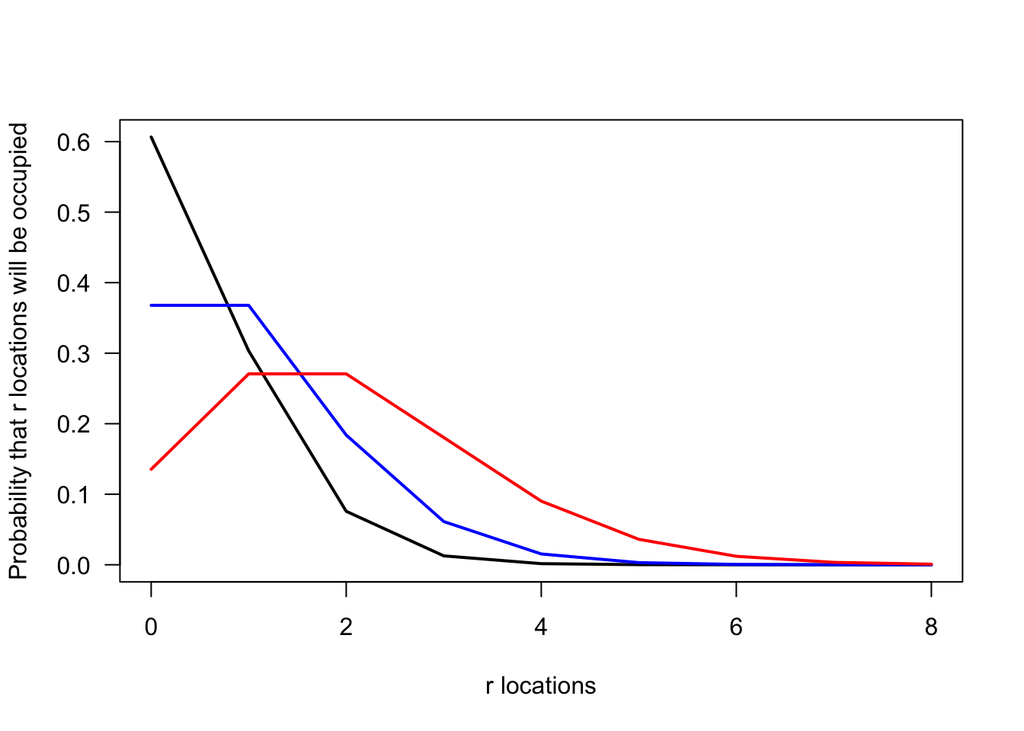

```r
lambda_0.5 <- 0.5
lambda_1.0 <- 1
lambda_2.0 <- 2

r <- seq(from = 0, to = 8, by = 1)

Pr_0.5 <- ((lambda_0.5^r)*exp(-lambda_0.5)) / factorial(r)
Pr_1.0 <- ((lambda_1.0^r)*exp(-lambda_1.0)) / factorial(r)
Pr_2.0 <- ((lambda_2.0^r)*exp(-lambda_2.0)) / factorial(r)

plot(x = r, y= Pr_0.5, las = 1, type = "l", lwd = 2, xlab = "r locations", ylab = "Probability that r locations will be occupied")
  lines(x = r, y= Pr_1.0, col = "blue", lwd = 2)
  lines(x = r, y= Pr_2.0, col = "red", lwd = 2)
```

As the avereage number of trees per plot, $\lambda$, increases, the probability that $r$ locations are occupies changes from being most plots near $0$ to most plots being around the avereage number of trees per plot, $\lambda$.

### 5.8

From the data in exercise 5.2, compute the average number of trees per quadrat and apply the Poisson distribution (use the average number of trees per quadrat as the esti- mate of λ). Graphically compare the Poisson distribution with the data.

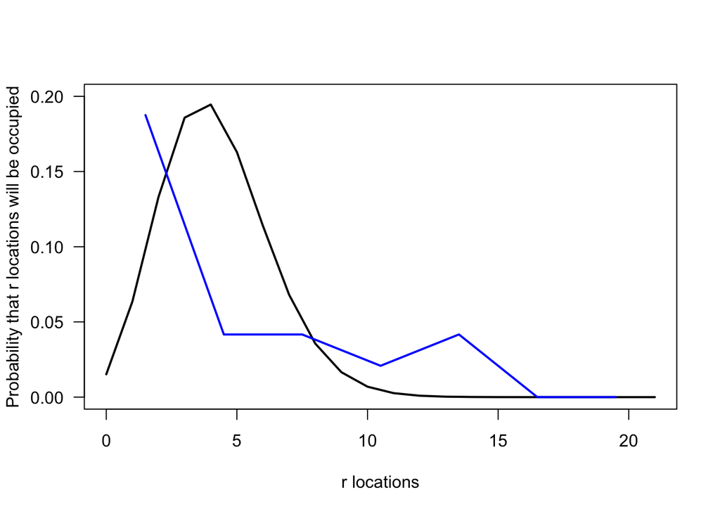

```r
lambda_5.2 <- mean(x = counts_bass)
r <- seq(from = 0, to = 21, by = 1)

Pr_5.2 <- ((lambda_5.2^r)*exp(-lambda_5.2)) / factorial(r)

plot(x = r, y= Pr_5.2, las = 1, type = "l", lwd = 2, xlab = "r locations", ylab = "Probability that r locations will be occupied", ylim = c(0, 0.2), xlim = c(0, 21))

bass.hist_3 <- hist(x = counts_bass, breaks = seq(from = 0, to = 21, by = 3), plot = F)

lines(x = bass.hist_3$mids, y = bass.hist_3$density, lwd = 2, col = "blue")
```

### 5.9

From the data in exercise 5.1, compute the average number of trees per quadrat and apply the Poisson distribution (use the average number of trees per quadrat as the estimate of λ). Graphically compare the Poisson distribution with the data.

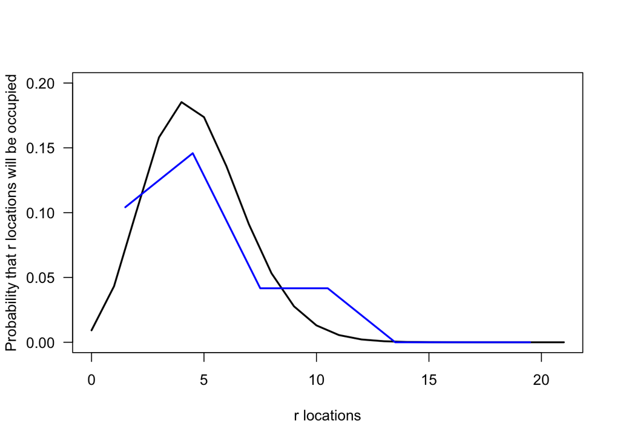

```r
lambda_5.1 <- mean(x = counts)
r <- seq(from = 0, to = 21, by = 1)

Pr_5.1 <- ((lambda_5.1^r)*exp(-lambda_5.1)) / factorial(r)

plot(x = r, y= Pr_5.1, las = 1, type = "l", lwd = 2, xlab = "r locations", ylab = "Probability that r locations will be occupied", ylim = c(0, 0.2), xlim = c(0, 21))

rand.hist_3 <- hist(x = counts, breaks = seq(from = 0, to = 21, by = 3), plot = F)

lines(x = rand.hist_3$mids, y = rand.hist_3$density, lwd = 2, col = "blue")
```

### 5.14

Remoras are small fish that hang around on the surface of sharks and feed off the remains of whatever the sharks eat. Frequently a given shark can have a large number of these fish on its surface, but sometimes individuals have none. The only way a remora can get from one shark to another is when the sharks come in contact with one another (or get close to one another). If 25% of the individuals in a particular shark population have remoras, what is the probability that a shark without remoras will acquire them upon encountering another shark? (Think of the contact process—what is in contact with what and what needs to happen for an unoccupied shark to become occupied.)

Proportion of sharks with remoras is 0.25; without remoras is 1 - 0.25 = 0.75. Probability of an unoccupied shark (0.75) encountering an occupied shark (0.25) is 0.75(0.25) = 0.1875. Probability of noccupied shark (0.25) encountering an unoccupied shark (0.75) is 0.75(0.25) = 0.1875. Therefore 0.1875 + 0.1875 = 0.375.

The proability of two occupied sharks encoutering is 0.25(0.25), which is 0.0625; the proability of two unoccupied sharks encoutering is 0.75(0.75) is 0.5625. These added to 0.375 = 1. so we know the probability of all of the outcomes.

### 5.15

Repeat exercise 5.14 but with the additional knowledge that every time one shark encounters another, there is a 50% chance that a remora (if present) will change sharks.

The probability of the transfer of remoras from an occupied to an unoccupied shark would be the contact probability times the rate of transfer, 0.5. That is, (0.5)(0.375) = 0.1875.

### 5.16

Let the proportion of sharks with remoras be equal to $p$ and the probability of a remora transfering between two sharks in contact be $m$. If that rate of change of the proportion of sharks occupied is take to be equal to the probability of transfer upon contact, write the general equation for that rate of change, in cnotinuous time.

Let the fraction of sharks with remoras be equal to p and the probability of a remora transferring between two sharks in contact be m. If the rate of change of the fraction of sharks occupied is taken to be equal to the probability of a transfer upon contact, write the general equation for that rate of change.

$$\frac{dp}{dt} = mp(1-p)$$

### 5.17

Graphically show the general relationship between $p^*$ and $e$ for values of $m$.

$$p^* = \frac{m-e}{m}$$

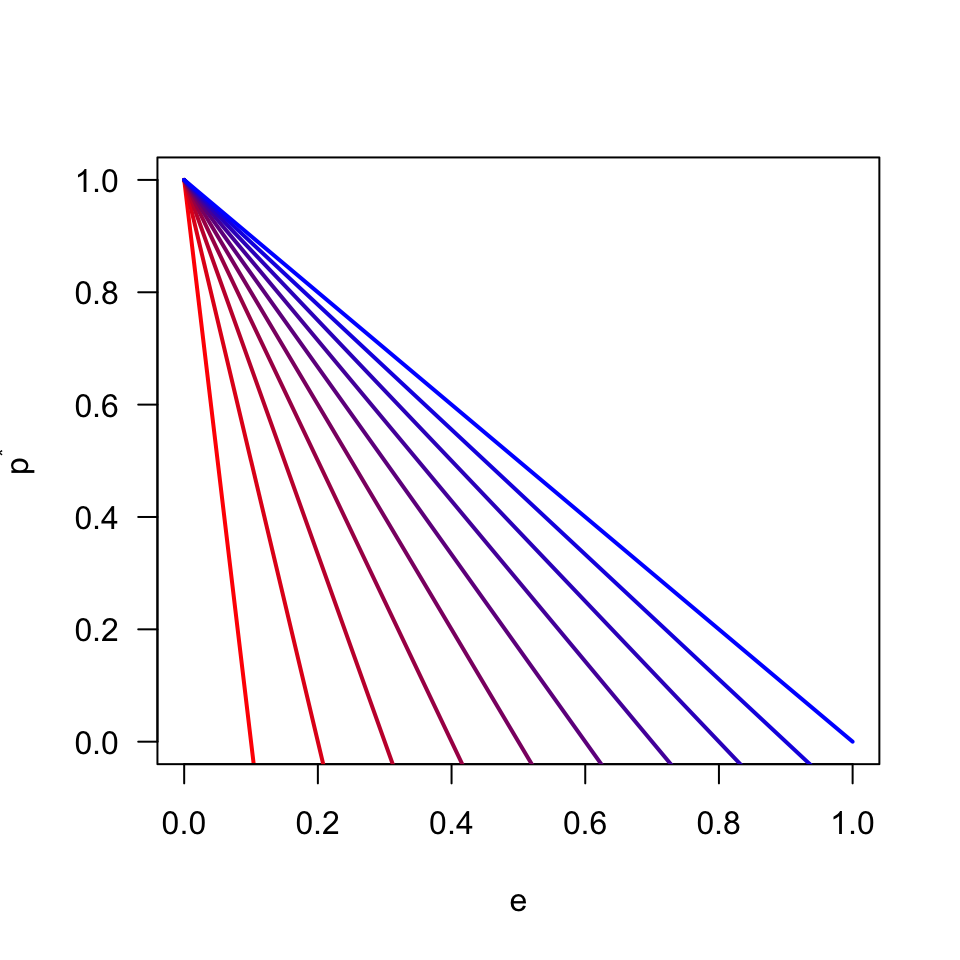

```r
m <- seq(0.1, 1, by = 0.1)
n.m <- length(m)
cols <- colorRampPalette(c("red", "blue"))(n.m)

for (i in 1:n.m) {
  e <- seq(from = 0, to = 1, by = 0.1)
  p.star <- 1 - (e/m[i])
  if (i == 1) {
    plot(x = e, y = p.star, ylab = bquote(p^"*"), xlab = "e", type = "l", lwd = 2, col = cols[i], las = 1, ylim = c(0, 1))
  } else {
    lines(x = e, y = p.star, lwd = 2, col = cols[i])
  }
}
```

### 5.18

Some populations may behave as metapopulations in the sense that there is a discontinuous distribution of individuals in space and a constant extinction rate of those patches, but the migration rate is independent of the proportion of habitats occupied (sometimes referred to as propagule rain). Presume that there is zero migration from patch to patch but a constant rain of individuals from outside the system. What would the equation for this situation be? What would the equilibrium value be? Graph the equilibrium as a function of the extinction rate (for propagule rain = 0.25), and com- pare it to the classic equation with m = 1).

Zero migration would mean that $m = 0$ from the equation $\frac{dp}{dt} = mp(1-p) - ep$, so $\frac{dp}{dt} = - ep$. This means that populations would only go extinct, which is so far consistent with the exercise. Next, we want to add immigrants that colonize unoccupied patches. If we call the immigrants $\delta$, the number of new patches occupied will be dependent only on those that are currently unoccupied, $(1-p)$; therefore, propagule rain would be $\delta (1-p)$. The full equation would be
$$\frac{dp}{dt} = \delta(1-p) - ep$$
. Setting the LHS to 0 to solve for the equilibrium
$$\begin{aligned}
\frac{dp}{dt} &= \delta (1-p) - ep \\
0 &= \delta (1-p) - ep \\
0 &= \delta - \delta p - ep \\
0 &= \delta - p(\delta + e) \\
p(\delta + e) &= \delta \\
p^* &= \frac{\delta}{\delta + e}
\end{aligned}$$

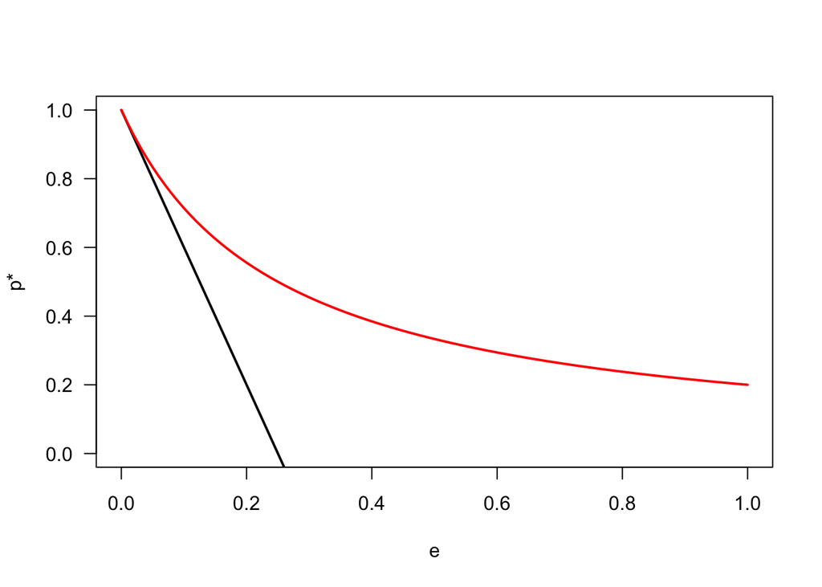

```r
e <- seq(from = 0, to = 1, by = 0.01)
m <- 0.25
delta <- m
levins.pstar <- 1 - e/m
rain.pstar <- delta/(delta + e)

plot(x = NA, type = "n", las = 1, xlab = "e", ylab = "p*", xlim = c(0, 1), ylim = c(0, 1))
lines(x = e, y = levins.pstar, lwd = 2)
lines(x = e, y = rain.pstar, lwd = 2, col = "red")
```